# Breast Cancer data analysis

Anu Narendran

August 23, 2016

Overview and Summary:

Breast cancer is considered to be the second leading cause of cancer deaths in women today. One of the main problems is to predict recurrent and non-recurrent events. The goal of this project is to investigate the ability of Naive Bayesian classification methodology in classifying or predicting the problems in Wisconsin Breast Cancer dataset. Naïve Bayes model is compared against another Linear model to see which prediction, give better results. Comparing the best models of Linear Model and Naive Bayes, Naive Bayes provide much superior models with an accuracy of 98% compared to the Linear Model with 89%.

## Initial set up

```r
rm(list = ls())
## Set path
current_path <- setwd("C:/Users/Anu/Downloads/Data Science/Quarter 2 - Methods for Data Analysis/Project/Breast Cancer")

# Install the necessary packages
reposURL <- "http://cran.rstudio.com/"
# install package with naive bayes if not alreay installed
if (!require("e1071")) {install.packages("e1071", dep=TRUE, repos=reposURL)} else {" e1071 is already installed "}
```

```
FALSE [1] " e1071 is already installed "
```

```r
# Now that the package is installed, we want to load the package so that we can use its functions
library(e1071)
```

## Read the data and take a look at a few records

```r
path = '.'
filePath <- file.path(path, 'breast-cancer-wisconsin-data.csv')
cancer.data <- read.csv(filePath, header = TRUE,
                       stringsAsFactors = FALSE)
head(cancer.data)
```

```
##        id Clump.Thickness Uniformity.of.Cell.Size Uniformity.of.Cell.Shape
## 1 1000025               5                       1                        1
## 2 1002945               5                       4                        4
## 3 1015425               3                       1                        1
## 4 1016277               6                       8                        8
## 5 1017023               4                       1                        1
## 6 1017122               8                      10                       10
##   Marginal.Adhesion Single.Epithelial.Cell.Size Bare.Nuclei
## 1                 1                           2           1
## 2                 5                           7          10
## 3                 1                           2           2
## 4                 1                           3           4
## 5                 3                           2           1
## 6                 8                           7          10
##   Bland.Chromatin Normal.Nucleoli Mitoses Class
## 1               3               1       1     2
## 2               3               2       1     2
## 3               3               1       1     2
## 4               3               7       1     2
## 5               3               1       1     2
## 6               9               7       1     4
```

```r
names(cancer.data)
```

```
##  [1] "id"                          "Clump.Thickness"
##  [3] "Uniformity.of.Cell.Size"     "Uniformity.of.Cell.Shape"
##  [5] "Marginal.Adhesion"           "Single.Epithelial.Cell.Size"
##  [7] "Bare.Nuclei"                 "Bland.Chromatin"
##  [9] "Normal.Nucleoli"             "Mitoses"
## [11] "Class"
```

```r
cols <-names(cancer.data) <- c('id','ct','ucsize','ucshape','ma','secs','bn','bc','nn','miti','class')
names(cancer.data)
```

```
##  [1] "id"      "ct"      "ucsize"  "ucshape" "ma"      "secs"    "bn"
##  [8] "bc"      "nn"      "miti"    "class"
```

```r
## Summary statistics
summary(cancer.data)
```

```
##        id                 ct             ucsize          ucshape
##  Min.   :   61634   Min.   : 1.000   Min.   : 1.000   Min.   : 1.000
##  1st Qu.:  870688   1st Qu.: 2.000   1st Qu.: 1.000   1st Qu.: 1.000
##  Median : 1171710   Median : 4.000   Median : 1.000   Median : 1.000
##  Mean   : 1071704   Mean   : 4.418   Mean   : 3.134   Mean   : 3.207
##  3rd Qu.: 1238298   3rd Qu.: 6.000   3rd Qu.: 5.000   3rd Qu.: 5.000
##  Max.   :13454352   Max.   :10.000   Max.   :10.000   Max.   :10.000
##        ma              secs             bn                  bc
##  Min.   : 1.000   Min.   : 1.000   Length:699         Min.   : 1.000
##  1st Qu.: 1.000   1st Qu.: 2.000   Class :character   1st Qu.: 2.000
##  Median : 1.000   Median : 2.000   Mode  :character   Median : 3.000
##  Mean   : 2.807   Mean   : 3.216                      Mean   : 3.438
##  3rd Qu.: 4.000   3rd Qu.: 4.000                      3rd Qu.: 5.000
##  Max.   :10.000   Max.   :10.000                      Max.   :10.000
##        nn              miti            class
##  Min.   : 1.000   Min.   : 1.000   Min.   :2.00
##  1st Qu.: 1.000   1st Qu.: 1.000   1st Qu.:2.00
##  Median : 1.000   Median : 1.000   Median :2.00
##  Mean   : 2.867   Mean   : 1.589   Mean   :2.69
##  3rd Qu.: 4.000   3rd Qu.: 1.000   3rd Qu.:4.00
##  Max.   :10.000   Max.   :10.000   Max.   :4.00
```

## How many benign and malignant cases

```r
table(cancer.data$class)
```

```
##
##   2   4
## 458 241
```

## # clean up the data and remove cases with NULL data

```r
dim(cancer.data)
```

```
## [1] 699  11
```

```r
cancer.data <- cancer.data[as.numeric(cancer.data$bn,na.omit=TRUE) < 11,]
cancer.data <- na.omit(cancer.data)
cancer.data$class <- as.numeric(cancer.data$class == "2")
cancer.data$bn <- as.numeric(cancer.data$bn)
```

Observation: Data looks clean. There are 16 records under feature ‘Bare.Nuclei’ which are NULL. Those records are removed before creating the model.

## Plot the correlations

Let us will look at the correlations between the variables. The following display shows these correlations.

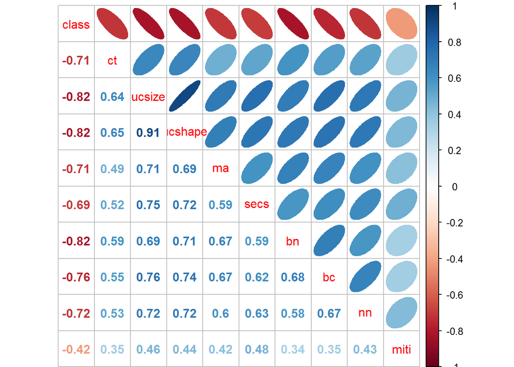

```r
cols <- c("class","ct","ucsize","ucshape","ma","secs","bn","bc","nn","miti")
cors = cor(cancer.data[, cols], method = 'pearson')
## Loading required package: corrplot
require(corrplot)
corrplot.mixed(cors, upper = "ellipse")
```

## Funtion for plotting the residual

```r
dist.ts = function(resid, col = 'residual', bins = 40){
  #  par(mfrow = c(1,2))
  #  temp = as.vector(df)
  breaks = seq(min(resid), max(resid), length.out = (bins + 1))
  hist(resid, breaks = breaks, main = paste('Distribution of ', col), xlab = col)
  qqnorm(resid, main = paste('Normal Q-Q plot of ', col))
  #  par(mfrow = c(1,1))
}
```

## Funtion to create a Global Linear Model

```r
model.glm <- function(train.datset,test.dataset,formula)
{
  # Create logistic regression
  glmModel <- glm(formula = formula,family = "binomial",data = train.datset)
  # Predict the outcomes for the test data. (predict type="response")
  predictedprobalities.GLM <- predict(glmModel,newdata=test.dataset, type =
                                        "response" )
  summary(predictedprobalities.GLM)
  actual <- ifelse(Test.cancer.data$class =="0", "2-Benign", "4-Malignant")
  threshold = 0.5
  #convert the predicted probabilities to predictions using a threshold
  predicted.GLM <- ifelse(predictedprobalities.GLM < threshold, "2-Benign",
                          "4-Malignant")

  #Confusion Matrix for Logistic Regression
  Model.GLM <-(table(predicted.GLM,actual,dnn = c("Predicted","Actual")))
  Model.GLM.sensitivity <- Model.GLM[1,1]/(Model.GLM[1,1] +
                                                 Model.GLM[1,2])
  Model.GLM.accuracy <- (Model.GLM[1,1] + Model.GLM[2,2])/
                                   (Model.GLM[1,1] +
                                      Model.GLM[1,2]+Model.GLM[2,1] +
                                      Model.GLM[2,2])
  print("Confusion Matrix for GLM Model")
  print(Model.GLM)
  print(paste("Sensitivity = ", Model.GLM.sensitivity))
  print(paste("Accuracy    = ", Model.GLM.accuracy))
  print(paste("Formula     = ", formula[2],formula[1],formula[3]))
}
```

## Preparing the test and training data sets

A large training set helps to give us a good model, but a large validation set increases the significance of the result you report. We need to strike a balance. A reasonable balance is 2/3 training and 1/3 validation. Furthermore, in splitting the data we want the training set to be representative of the general population as far as this particular problem goes.

```r
# Funtion for partitioning the test and training data set based on the fraction passed as the input
PartitionExact <- function(dataSet, fractionOfTest)
{
  numberOfRows <- nrow(dataSet)

  quantileValue <- quantile(runif(numberOfRows),fractionOfTest)
  testFlag <- runif(numberOfRows) <= quantileValue

  testingData <- dataSet[testFlag, ]
  trainingData <- dataSet[!testFlag, ]
  dataSetSplit <- list(trainingData=trainingData, testingData=testingData)

}
# Set repeatable random seed.
set.seed(4)

# Partition data between training and testing sets
DataSplit <- PartitionExact(cancer.data, fractionOfTest=0.3)
Test.cancer.data <- DataSplit$testingData
Train.cancer.data <-DataSplit$trainingData
nrow(Test.cancer.data)
```

```
## [1] 200
```

```r
nrow(Train.cancer.data)
```

```
## [1] 483
```

```r
table(Test.cancer.data$class)
```

```
##
##   0   1
##  74 126
```

# Stepwise Regression - Model 1 with all features

Create the first linear model with all the features. Then perform stepwise model selection by AIC.

```r
#install.packages("MASS")
library(MASS)
#Use stepwise regression to select features  - Model 1 with all features
formula1 <- class ~ 0 + ct + ucsize + ucshape + ma + secs + bn + bc + nn + miti
glmModel1.all <- glm(formula = formula1,family = "binomial",data = Train.cancer.data)
glm.step1 = stepAIC(glmModel1.all, direction = 'back')
```

```
## Start:  AIC=390.65
## class ~ 0 + ct + ucsize + ucshape + ma + secs + bn + bc + nn +
##     miti
##
##           Df Deviance    AIC
## - ucshape  1   373.89 389.89
## <none>         372.65 390.65
## - ma       1   375.15 391.15
## - miti     1   383.07 399.07
## - nn       1   394.60 410.60
## - bc       1   396.33 412.33
## - ct       1   405.04 421.04
## - ucsize   1   424.32 440.32
## - secs     1   431.97 447.97
## - bn       1   442.93 458.93
##
## Step:  AIC=389.89
## class ~ ct + ucsize + ma + secs + bn + bc + nn + miti - 1
##
##          Df Deviance    AIC
## <none>        373.89 389.89
## - ma      1   376.38 390.38
## - miti    1   384.10 398.10
## - bc      1   397.81 411.81
## - nn      1   398.44 412.44
## - ct      1   405.11 419.11
## - secs    1   433.13 447.13
## - bn      1   447.46 461.46
## - ucsize  1   477.01 491.01
```

```r
summary(glm.step1)
```

```
##
## Call:
## glm(formula = class ~ ct + ucsize + ma + secs + bn + bc + nn +
##     miti - 1, family = "binomial", data = Train.cancer.data)
##
## Deviance Residuals:
##     Min       1Q   Median       3Q      Max
## -3.7438  -0.0740   0.4989   0.7618   3.8656
##
## Coefficients:
##        Estimate Std. Error z value Pr(>|z|)
## ct      0.35579    0.06800   5.232 1.67e-07 ***
## ucsize -1.09920    0.13814  -7.957 1.76e-15 ***
## ma     -0.13926    0.08865  -1.571  0.11623
## secs    0.79451    0.11628   6.833 8.34e-12 ***
## bn     -0.55271    0.07419  -7.450 9.36e-14 ***
## bc      0.49089    0.10680   4.596 4.30e-06 ***
## nn     -0.37859    0.08027  -4.717 2.40e-06 ***
## miti    0.33196    0.10571   3.140  0.00169 **
## ---
## Signif. codes:  0 '***' 0.001 '**' 0.01 '*' 0.05 '.' 0.1 ' ' 1
##
## (Dispersion parameter for binomial family taken to be 1)
##
##     Null deviance: 669.58  on 483  degrees of freedom
## Residual deviance: 373.89  on 475  degrees of freedom
## AIC: 389.89
##
## Number of Fisher Scoring iterations: 6
```

```r
glm.step1$anova
```

```
## Stepwise Model Path
## Analysis of Deviance Table
##
## Initial Model:
## class ~ 0 + ct + ucsize + ucshape + ma + secs + bn + bc + nn +
##     miti
##
## Final Model:
## class ~ ct + ucsize + ma + secs + bn + bc + nn + miti - 1
##
##
##        Step Df Deviance Resid. Df Resid. Dev      AIC
## 1                             474   372.6487 390.6487
## 2 - ucshape  1 1.244161       475   373.8928 389.8928
```

As per the stepwise regression we found that if we remove the feature ‘Uniformity.of.Cell.Shape’, we get the best model. Thus the best model is the following: class ~ ct + ucsize + ma + secs + bn + bc + nn + miti - 1

## Stepwise Regression - Model 2 with features suggested by ANOVA

```r
formula2 <- class ~ ct + ucsize + ma + secs + bn + bc + nn + miti - 1
glmModel2 <- glm(formula = formula2,family = "binomial",data = Train.cancer.data)
glm.step2 = stepAIC(glmModel2, direction = 'both')
```

```
## Start:  AIC=389.89
## class ~ ct + ucsize + ma + secs + bn + bc + nn + miti - 1
##
##          Df Deviance    AIC
## <none>        373.89 389.89
## - ma      1   376.38 390.38
## - miti    1   384.10 398.10
## - bc      1   397.81 411.81
## - nn      1   398.44 412.44
## - ct      1   405.11 419.11
## - secs    1   433.13 447.13
## - bn      1   447.46 461.46
## - ucsize  1   477.01 491.01
```

```r
summary(glm.step2)
```

```
##
## Call:
## glm(formula = class ~ ct + ucsize + ma + secs + bn + bc + nn +
##     miti - 1, family = "binomial", data = Train.cancer.data)
##
## Deviance Residuals:
##     Min       1Q   Median       3Q      Max
## -3.7438  -0.0740   0.4989   0.7618   3.8656
##
## Coefficients:
##        Estimate Std. Error z value Pr(>|z|)
## ct      0.35579    0.06800   5.232 1.67e-07 ***
## ucsize -1.09920    0.13814  -7.957 1.76e-15 ***
## ma     -0.13926    0.08865  -1.571  0.11623
## secs    0.79451    0.11628   6.833 8.34e-12 ***
## bn     -0.55271    0.07419  -7.450 9.36e-14 ***
## bc      0.49089    0.10680   4.596 4.30e-06 ***
## nn     -0.37859    0.08027  -4.717 2.40e-06 ***
## miti    0.33196    0.10571   3.140  0.00169 **
## ---
## Signif. codes:  0 '***' 0.001 '**' 0.01 '*' 0.05 '.' 0.1 ' ' 1
##
## (Dispersion parameter for binomial family taken to be 1)
##
##     Null deviance: 669.58  on 483  degrees of freedom
## Residual deviance: 373.89  on 475  degrees of freedom
## AIC: 389.89
##
## Number of Fisher Scoring iterations: 6
```

```r
glm.step2$anova
```

```
## Stepwise Model Path
## Analysis of Deviance Table
##
## Initial Model:
## class ~ ct + ucsize + ma + secs + bn + bc + nn + miti - 1
##
## Final Model:
## class ~ ct + ucsize + ma + secs + bn + bc + nn + miti - 1
##
##
##   Step Df Deviance Resid. Df Resid. Dev      AIC
## 1                        475   373.8928 389.8928
```

As per the analysis, this model seems to have the best standard deviation and AIC. Thus this is considered as the best model so far. Let us try another model with different set of features.

## Stepwise Regression - Model 3 with with different features

```r
formula3 <- class ~ 0 + ct + ucsize + ucshape + ma  + bn + bc
glmModel3 <- glm(formula = formula3,family = "binomial",data = Train.cancer.data)
glm.step3 = stepAIC(glmModel3, direction = 'both')
```

```
## Start:  AIC=480
## class ~ 0 + ct + ucsize + ucshape + ma + bn + bc
##
##           Df Deviance    AIC
## - ma       1   468.17 478.17
## - ucshape  1   469.74 479.74
## <none>         468.00 480.00
## - ucsize   1   500.73 510.73
## - bc       1   501.54 511.54
## - ct       1   530.50 540.50
## - bn       1   531.59 541.59
##
## Step:  AIC=478.17
## class ~ ct + ucsize + ucshape + bn + bc - 1
##
##           Df Deviance    AIC
## - ucshape  1   469.92 477.92
## <none>         468.17 478.17
## + ma       1   468.00 480.00
## - ucsize   1   502.06 510.06
## - bc       1   503.75 511.75
## - ct       1   531.02 539.02
## - bn       1   533.29 541.29
##
## Step:  AIC=477.92
## class ~ ct + ucsize + bn + bc - 1
##
##           Df Deviance    AIC
## <none>         469.92 477.92
## + ucshape  1   468.17 478.17
## + ma       1   469.74 479.74
## - bc       1   504.78 510.78
## - ct       1   531.19 537.19
## - bn       1   539.25 545.25
## - ucsize   1   556.61 562.61
```

```r
summary(glm.step3)
```

```
##
## Call:
## glm(formula = class ~ ct + ucsize + bn + bc - 1, family = "binomial",
##     data = Train.cancer.data)
##
## Deviance Residuals:
##     Min       1Q   Median       3Q      Max
## -2.7487  -0.2001   0.6824   0.9652   3.3991
##
## Coefficients:
##        Estimate Std. Error z value Pr(>|z|)
## ct      0.40847    0.05865   6.964 3.31e-12 ***
## ucsize -0.72882    0.09491  -7.679 1.61e-14 ***
## bn     -0.44172    0.06053  -7.297 2.93e-13 ***
## bc      0.46709    0.08598   5.433 5.55e-08 ***
## ---
## Signif. codes:  0 '***' 0.001 '**' 0.01 '*' 0.05 '.' 0.1 ' ' 1
##
## (Dispersion parameter for binomial family taken to be 1)
##
##     Null deviance: 669.58  on 483  degrees of freedom
## Residual deviance: 469.92  on 479  degrees of freedom
## AIC: 477.92
##
## Number of Fisher Scoring iterations: 5
```

```r
glm.step3$anova
```

```
## Stepwise Model Path
## Analysis of Deviance Table
##
## Initial Model:
## class ~ 0 + ct + ucsize + ucshape + ma + bn + bc
##
## Final Model:
## class ~ ct + ucsize + bn + bc - 1
##
##
##        Step Df  Deviance Resid. Df Resid. Dev      AIC
## 1                              477   467.9990 479.9990
## 2      - ma  1 0.1697869       478   468.1688 478.1688
## 3 - ucshape  1 1.7519435       479   469.9208 477.9208
```

Stepwise regression suggests that if we remove the feature ‘Uniformity.of.Cell.Shape’ and Marginal.Adhesion from the current model, we get a better model. Thus the next model is the following: class ~ ct + ucsize + bn + bc - 1 ## Stepwise Regression - Model 4 - Better model from Model 3 suggested by ANOVA

```r
formula4 <- class ~ ct + ucsize + bn + bc - 1
glmModel4 <- glm(formula = formula4,family = "binomial",data = Train.cancer.data)
glm.step4 = stepAIC(glmModel4, direction = 'both')
```

```
## Start:  AIC=477.92
## class ~ ct + ucsize + bn + bc - 1
##
##          Df Deviance    AIC
## <none>        469.92 477.92
## - bc      1   504.78 510.78
## - ct      1   531.19 537.19
## - bn      1   539.25 545.25
## - ucsize  1   556.61 562.61
```

```r
summary(glm.step4)
```

```
##
## Call:
## glm(formula = class ~ ct + ucsize + bn + bc - 1, family = "binomial",
##     data = Train.cancer.data)
##
## Deviance Residuals:
##     Min       1Q   Median       3Q      Max
## -2.7487  -0.2001   0.6824   0.9652   3.3991
##
## Coefficients:
##        Estimate Std. Error z value Pr(>|z|)
## ct      0.40847    0.05865   6.964 3.31e-12 ***
## ucsize -0.72882    0.09491  -7.679 1.61e-14 ***
## bn     -0.44172    0.06053  -7.297 2.93e-13 ***
## bc      0.46709    0.08598   5.433 5.55e-08 ***
## ---
## Signif. codes:  0 '***' 0.001 '**' 0.01 '*' 0.05 '.' 0.1 ' ' 1
##
## (Dispersion parameter for binomial family taken to be 1)
##
##     Null deviance: 669.58  on 483  degrees of freedom
## Residual deviance: 469.92  on 479  degrees of freedom
## AIC: 477.92
##
## Number of Fisher Scoring iterations: 5
```

```r
glm.step4$anova
```

```
## Stepwise Model Path
## Analysis of Deviance Table
##
## Initial Model:
## class ~ ct + ucsize + bn + bc - 1
##
## Final Model:
## class ~ ct + ucsize + bn + bc - 1
##
##
##   Step Df Deviance Resid. Df Resid. Dev      AIC
## 1                        479   469.9208 477.9208
```

Even though this model is better than the previous model from Step 3, the Standard deviation of the residuals and the AIC suggest that the model from Step 2 is the best model. ## Compare the residuals of all the 4 GLM models Let us compare the residuals of all the 4 GLM models analyzed above to see how the plot looks like.

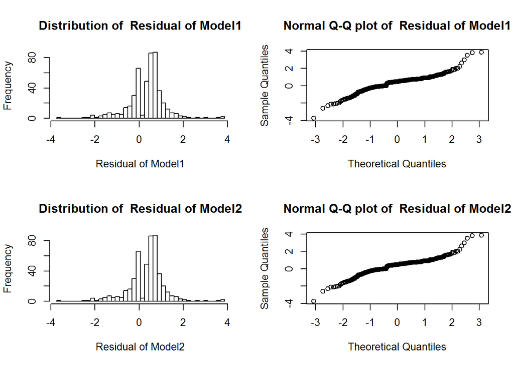

```r
par(mfrow = c(2,2))
resid <- resid(glm.step1)
dist.ts(resid,col = "Residual of Model1")
resid <- resid(glm.step2)
dist.ts(resid,col = "Residual of Model2")
```

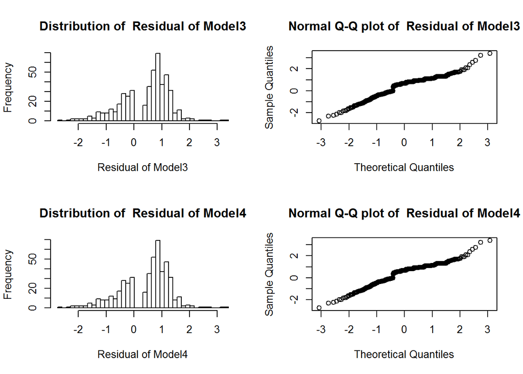

```r
resid <- resid(glm.step3)
dist.ts(resid,col = "Residual of Model3")
resid <- resid(glm.step4)
dist.ts(resid,col = "Residual of Model4")
```

```r
par(mfrow = c(1,1))
```

Looks like the first and the second models looks better than the third and fourth models.

## Print the Confution Matrix for all the 4 GLM models

```r
Model.GLM1<-model.glm(Train.cancer.data,Test.cancer.data,formula1)
```

```
## [1] "Confusion Matrix for GLM Model"
##              Actual
## Predicted     2-Benign 4-Malignant
##   2-Benign          61          10
##   4-Malignant       13         116
## [1] "Sensitivity =  0.859154929577465"
## [1] "Accuracy    =  0.885"
## [1] "Formula     =  class ~ 0 + ct + ucsize + ucshape + ma + secs + bn + bc + nn + miti"
```

```r
Model.GLM2<-model.glm(Train.cancer.data,Test.cancer.data,formula2)
```

```
## [1] "Confusion Matrix for GLM Model"
##              Actual
## Predicted     2-Benign 4-Malignant
##   2-Benign          62          11
##   4-Malignant       12         115
## [1] "Sensitivity =  0.849315068493151"
## [1] "Accuracy    =  0.885"
## [1] "Formula     =  class ~ ct + ucsize + ma + secs + bn + bc + nn + miti - 1"
```

```r
Model.GLM3<-model.glm(Train.cancer.data,Test.cancer.data,formula3)
```

```
## [1] "Confusion Matrix for GLM Model"
##              Actual
## Predicted     2-Benign 4-Malignant
##   2-Benign          65          28
##   4-Malignant        9          98
## [1] "Sensitivity =  0.698924731182796"
## [1] "Accuracy    =  0.815"
## [1] "Formula     =  class ~ 0 + ct + ucsize + ucshape + ma + bn + bc"
```

```r
Model.GLM4<-model.glm(Train.cancer.data,Test.cancer.data,formula4)
```

```
## [1] "Confusion Matrix for GLM Model"
##              Actual
## Predicted     2-Benign 4-Malignant
##   2-Benign          64          30
##   4-Malignant       10          96
## [1] "Sensitivity =  0.680851063829787"
## [1] "Accuracy    =  0.8"
## [1] "Formula     =  class ~ ct + ucsize + bn + bc - 1"
```

As per the Confustion Matrix, the first model seems to be the best with an accuracy of 89% and Sensitivity of 86% .

The formula is, class ~ 0 + ct + ucsize + ucshape + ma + secs + bn + bc + nn + miti.

Now let us looks at the Naive Bayes models to see if they provide better models than linear models.

## Funtions to create NB Models

Given below are funtions to create the best Naive Bayes models based on accuracy and sensitivity.

```r
# Funtion to create one Naive Bayes models based on the input dataset and formula
model.naiveBayes <- function(train.datset,test.dataset,formula)
{

  # Create Naive Bayes model
  NaiveModel <- naiveBayes(formula = as.formula(formula),data = train.datset,na.action = na.pass,laplace = 3)
  # Predict the outcomes for the test data. (predict type="raw")
  predictedprobalities.Naive <- predict(NaiveModel,newdata = test.dataset, type = "raw")
  actual <- ifelse(test.dataset$class =="0", "2-Benign", "4-Malignant")
  threshold = 0.5
  predicted.NaiveBayes <-ifelse(predictedprobalities.Naive[,1] > threshold, "2-Benign", "4-Malignant")
  table.NB = cbind(test.dataset,predicted.NaiveBayes,actual, (ifelse(predicted.NaiveBayes == actual,"0","1")) )
# Add a new column which shows error in prediction
  colnames(table.NB)[14] <- "Error"
  new.table.NB.error = table.NB[which(table.NB$Error == '1'),]
  table <-table(predicted.NaiveBayes,actual,dnn = c("Predicted","Actual"))
}

# Funtion to find the best Naive Bayes Model based on Accuracy
model.naiveBayes.best.accuracy <- function(train.datset1,test.dataset1)
{
  library(simpleboot)

  current.model <-NULL
  best.model.accuracy     <- 0
  best.model.sensitivity  <- 0
  best.model.specificity  <- 0
  best.model <- NULL

    ## Find the feature names
  varnames <- names(train.datset1)[2:9]

  for (k in 1:length(varnames)) {
   combs = combn(varnames, k) # Find all k-wise combination
   ncombs <-ncol(combs)

    # find the total number of k element wise combinations and create
    # formulas for each of the list

   for(j in 1:ncombs)
   {
      varlist <- combs[,j]

#  Create formula based on the varlist
      formula1 <-paste(names(train.datset1)[11], "~ " )
      for (i in varlist) {
        formula1 <-paste(formula1, i," + " )
      }
      formula1 <-paste(formula1, 0)
      # Create the new model using the formula
      current.model<- model.naiveBayes(train.datset =
                                         train.datset1,test.dataset =
                                         test.dataset1,formula=formula1)
      # Calculate accuracy of the current model and compare it with the
      # best model so far
      # Accuracy = (TN + TP)/(TN+TP+FN+FP) = (Number of correct
      #             assessments)/Number of all assessments)
      current.model.accuracy <- (current.model[1,1] + current.model[2,2])/
                                   (current.model[1,1] + current.model[1,2]
                                    + current.model[2,1] +
                                      current.model[2,2])
      current.model.sensitivity <- current.model[1,1]/(current.model[1,1] +
                                                         current.model[2,1])

      current.model.specificity <- current.model[2,2]/(current.model[2,2] +
                                                         current.model[1,2])


      if(current.model.accuracy > best.model.accuracy)
      {
        best.model <- current.model
        best.model.accuracy <-current.model.accuracy
        best.model.sensitivity <-current.model.sensitivity
        best.model.specificity <-current.model.specificity
        best.formula <-formula1
      }
   }
  }
    print("Best model based on Accuracy")
    print(best.model)
    print(best.formula)
    print(paste("Accuracy    :",best.model.accuracy))
    print(paste("Sensitivity :",best.model.sensitivity))
    print(paste("Specificity :",best.model.specificity))
}


# Funtion to find the best Naive Bayes Model based on Sensitivity
model.naiveBayes.best.sensitivity <- function(train.datset1,test.dataset1)
{
  library(simpleboot)

  current.model <-NULL
  best.model.accuracy     <- 0
  best.model.sensitivity  <- 0
  best.model.specificity  <- 0
  best.model <- NULL

  ## Find the feature names
  varnames <- names(train.datset1)[2:9]

  for (k in 1:length(varnames)) {
    combs = combn(varnames, k) # Find all k-wise combination
    ncombs <-ncol(combs)
 # find the total number of k element wise combinations and create formulas
 # for each of the list
    for(j in 1:ncombs)
    {
      varlist <- combs[,j]
      #  Create formula based on the varlist
      formula1 <-paste(names(train.datset1)[11], "~ " )
      for (i in varlist) {
        formula1 <-paste(formula1, i," + " )
      }
      formula1 <-paste(formula1, 0)
      # Create the new model using the formula
      current.model<- model.naiveBayes(train.datset =
                                         train.datset1,test.dataset =
                                         test.dataset1,formula=formula1)
      # Calculate sensitivity of the current model and compare it with the
      # best model so far
      # Sensitivity = TP/(TP + FN) = (Number of true positive
      #               assessment)/(Number of all positive assessment)

      current.model.accuracy <- (current.model[1,1] + current.model[2,2])/
                                   (current.model[1,1] + current.model[1,2]
                                    + current.model[2,1] +
                                      current.model[2,2])
      current.model.sensitivity <- current.model[1,1]/(current.model[1,1] +
                                                         current.model[2,1])
      current.model.specificity <- current.model[2,2]/(current.model[2,2] +
                                                         current.model[1,2])


      if(current.model.sensitivity > best.model.sensitivity)
      {
        best.model <- current.model
        best.model.accuracy <-current.model.accuracy
        best.model.sensitivity <-current.model.sensitivity
        best.model.specificity <-current.model.specificity
        best.formula <-formula1
      }
    }
  }
  print("Best model based on Sensitivity")
  print(best.model)
  print(best.formula)
  print(paste("Accuracy    :",best.model.accuracy))
  print(paste("Sensitivity :",best.model.sensitivity))
  print(paste("Specificity :",best.model.specificity))
}

# Funtion to find the best Naive Bayes Model based on Specificity
model.naiveBayes.best.specificity <- function(train.datset1,test.dataset1)
{
  library(simpleboot)

  current.model <-NULL
  best.model.accuracy     <- 0
  best.model.sensitivity  <- 0
  best.model.specificity  <- 0
  best.model <- NULL

  ## Find the feature names
  varnames <- names(train.datset1)[2:9]

  for (k in 1:length(varnames)) {
    combs = combn(varnames, k) # Find all k-wise combination
    ncombs <-ncol(combs)
 # find the total number of k element wise combinations and create formulas
 # for each of the list
    for(j in 1:ncombs)
    {
      varlist <- combs[,j]
      #  Create formula based on the varlist
      formula1 <-paste(names(train.datset1)[11], "~ " )
      for (i in varlist) {
        formula1 <-paste(formula1, i," + " )
      }
      formula1 <-paste(formula1, 0)
      # Create the new model using the formula
      current.model<- model.naiveBayes(train.datset =
                                         train.datset1,test.dataset =
                                         test.dataset1,formula=formula1)
      # Calculate sensitivity of the current model and compare it with the
      # best model so far
      #Specificity = TN/(TN + FP) = (Number of true negative
      #               assessment)/(Number of all negative assessment)

      current.model.accuracy <- (current.model[1,1] + current.model[2,2])/
                                   (current.model[1,1] + current.model[1,2]
                                    + current.model[2,1] +
                                      current.model[2,2])

      current.model.sensitivity <- current.model[1,1]/(current.model[1,1] +
                                                         current.model[2,1])

      current.model.specificity <- current.model[2,2]/(current.model[2,2] +
                                                         current.model[1,2])

      if(current.model.specificity > best.model.specificity)
      {
        best.model <- current.model
        best.model.accuracy <-current.model.accuracy
        best.model.sensitivity <-current.model.sensitivity
        best.model.specificity <-current.model.specificity
        best.formula <-formula1
      }
    }
  }
  print("Best model based on Specificity")
  print(best.model)
  print(best.formula)
  print(paste("Accuracy    :",best.model.accuracy))
  print(paste("Sensitivity :",best.model.sensitivity))
  print(paste("Specificity :",best.model.specificity))

  }
```

## Best Naive Bayes model based on Sensitivity, Specificity and Accuracy

Sensitivity is the proportion of true positives that are correctly identified by a diagnostic test. It shows how good the test is at detecting a disease. Specificity is the proportion of the true negatives correctly identified by a diagnostic test. It suggests how good the test is at identifying normal(negative) condition. Accuracy is the proportion of true results, either true positive or true negative, in a population. It measures the degree of veracity of a diagnostic test on a condition.

The numerical values of sensitivity represents the probability of a diagnostic test identifies patients who do in fact have the disease. The higher the numerical value of sensitivity, the less likely diagnostic test returns false-positive results. For example, if sensitivity = 99%, it means: when we conduct a diagnostic test on a patient with certain disease, there is 99% of chance, this patient will be identified as positive. A test with high sensitivity tents to capture all possible positive conditions without missing anyone. Thus a test with high sensitivity is often used to screen for disease.

```r
# Best Naive Bayes Model based on Sensitivity
Model.best.NB.sensitivity <- model.naiveBayes.best.sensitivity(train.datset1 = Train.cancer.data,test.dataset1 = Test.cancer.data)
```

```
## [1] "Best model based on Sensitivity"
##              Actual
## Predicted     2-Benign 4-Malignant
##   2-Benign          72           3
##   4-Malignant        2         123
## [1] "class ~  ct  +  ucshape  +  ma  +  0"
## [1] "Accuracy    : 0.975"
## [1] "Sensitivity : 0.972972972972973"
## [1] "Specificity : 0.976190476190476"
```

```r
# Best Naive Bayes Model based on Specificity
Model.best.NB.specificity <- model.naiveBayes.best.specificity(train.datset1 = Train.cancer.data,test.dataset1 = Test.cancer.data)
```

```
## [1] "Best model based on Specificity"
##              Actual
## Predicted     2-Benign 4-Malignant
##   2-Benign          64           1
##   4-Malignant       10         125
## [1] "class ~  ct  +  bc  +  0"
## [1] "Accuracy    : 0.945"
## [1] "Sensitivity : 0.864864864864865"
## [1] "Specificity : 0.992063492063492"
```

```r
# Best Naive Bayes Model based on Accuracy
Model.best.NB.accuracy <- model.naiveBayes.best.accuracy(train.datset1 = Train.cancer.data,test.dataset1 = Test.cancer.data)
```

```
## [1] "Best model based on Accuracy"
##              Actual
## Predicted     2-Benign 4-Malignant
##   2-Benign          72           2
##   4-Malignant        2         124
## [1] "class ~  ct  +  ucsize  +  ucshape  +  bn  +  nn  +  0"
## [1] "Accuracy    : 0.98"
## [1] "Sensitivity : 0.972972972972973"
## [1] "Specificity : 0.984126984126984"
```

Conclusion :

Given the models with best sensitivity, specificity and accuracy we choose the one with best sensitivity and then the next factor as accuracy. The sensitivity of a clinical test refers to the ability of the test to correctly identify those patients with the disease. A test with 100% sensitivity correctly identifies all patients with the disease. A test with 80% sensitivity detects 80% of patients with the disease (true positives) but 20% with the disease go undetected (false negatives).

Comparing the best models of Linear Model and Naive Bayes, Naive Bayes provide superior models than the Linear Model.

Thus the best Naive Bayes model is, class ~ ct + ucsize + ucshape + bn + nn + 0 It has an Accuracy of 98% , Sensitivity of 97% and Specificity of 98%.